# Universidad de Costa Rica

Pronóstico Transferencias Corrientes

# Proyecto Final

Andrés Anguedas Patricia Delvó Fiorella Laurito

## Introducción

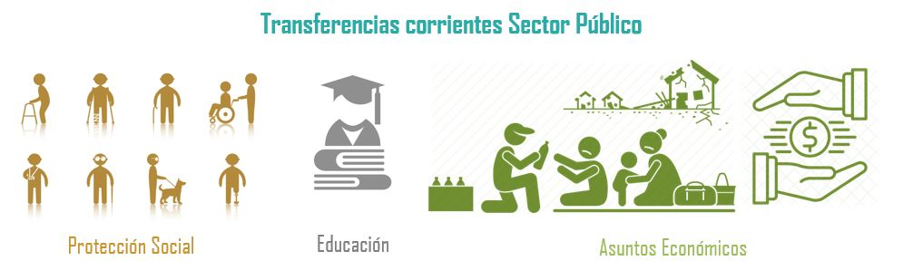

## Objetivo de Investigación

> Pronosticar las transferencias corrientes de Costa Rica en el período julio 2018 a junio 2020 con base en datos del Sistema Integrado de Gestión de Administración Financiera (SIGAF) y liquidaciones mensuales del Gobierno con una periodicidad mensual para el periodo comprendido de enero 2007 a junio 2018.

## Metodología

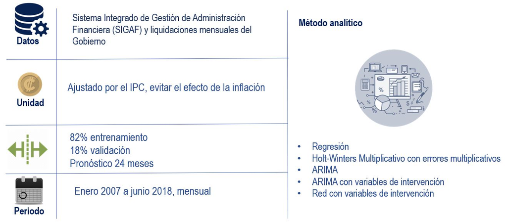

## Resultados

#### Análisis Descriptivo

```r
serie2 <- ts(transferencias$monto_real, start = c(2007, 1), end = c(2018, 6), frequency = 12)


#highchart() %>%
 # hc_xAxis(title= list(text = "Mes"),categories = format(datos$Mes,format="%b %Y"),
#           type="datetime",tickInterval = 8) %>%
 # hc_add_series(name = "Cartera", data = datos$Cartera_credito, color="darkturquoise") %>%
  #hc_yAxis(title = list(text = "Colones"),min=125000, max=325000,
   #        labels = list(format = "{value}")) %>%
  #hc_tooltip(crosshairs = T,valueDecimals = 1)%>%
  #hc_title(text = "Gráfico 1 <br> Cartera Crediticia de Enero 2010 a Setiembre 2018 ",
   #        margin = 20, align = "center",
    #       style = list(color = "#black", useHTML = TRUE, fontWeight = "bold")) %>%
  #hc_subtitle(text = "Millones de colones",
   #           align = "center")  %>%
    #  hc_chart(
     #   zoomType = "xy"
    #  )%>%
  #hc_size(width = 800,height=600)


highchart(type="stock") %>%
  hc_add_series(name = "Tranferencias", data = serie2, color="darkturquoise") %>%
  hc_yAxis(title = list(text = "Colones"),
           labels = list(format = "{value}")) %>%
  hc_tooltip(crosshairs = T,valueDecimals = 1)%>%
  hc_title(text = "Gráfico 1 <br> Tranferencias corrientes de Enero 2007 a Junio 2018 ",
           margin = 20, align = "center",
           style = list(color = "#black", useHTML = TRUE, fontWeight = "bold")) %>%
  hc_subtitle(text = "Millones de colones",
              align = "center")  %>%
      hc_chart(
        zoomType = "xy"
      )%>%
  hc_size(width = 800,height=600)
```

[interactive chart not shown]

Elaboración con datos de Sistema Integrado para la Gestión de la Administración Financiera y liquidaciones mensuales del Gobierno 2007 a 2018

#### Descomposición de la serie

```r
x <- stl(serie2, s.window = "periodic", robust = TRUE)

sea<-x$time.series[,1]
tre<-x$time.series[,2]
irreg<-x$time.series[,3]

titulo<-hchart(serie2,color="white",showInLegend = FALSE)%>%
  hc_title(text = "Gráfico 2 <br> Descomposición de  tranferencias corrientes de Enero 2007 a Junio 2018 ",
           margin = 20, align = "center",
           style = list(color = "#black", useHTML = TRUE, fontWeight = "bold")) %>%
  hc_subtitle(text = "Millones de colones",
              align = "center") %>% hc_add_theme(hc_theme_null()) %>%
  hc_size(width = 500, height = 50)

serie<-hchart(serie2,color="orange") %>% hc_yAxis(title= list(text = "Cartera"),
           labels = list(format = "{value}"))%>%
  hc_size(width = 500, height = 175)
estac<-hchart(sea,color="deeppink") %>% hc_yAxis(title= list(text = "Estacionalidad"),
           labels = list(format = "{value}"))%>%
  hc_size(width = 500, height = 175)
tend<-hchart(tre,color="darkturquoise") %>% hc_yAxis(title= list(text = "Tendencia"),
           labels = list(format = "{value}"))%>%
  hc_size(width = 500, height = 175)
irregu<-hchart(irreg,color="greenyellow",type="column") %>% hc_yAxis(title= list(text = "Irregularidad"),
           labels = list(format = "{value}"))%>%
  hc_size(width = 500, height = 175)

hw_grid(titulo,
        serie,
          estac,
          tend,
          irregu, ncol = 1)
```

[interactive chart not shown]

Elaboración con datos de Sistema Integrado para la Gestión de la Administración Financiera y liquidaciones mensuales del Gobierno 2007 a 2018

#### Regresión Longitudinal

| Resultados del modelo | Resultados del modelo Estimado | Resultados del modelo Error Estándar | Resultados del modelo Valor T | Resultados del modelo Pr(>\|t\|) |
| --- | --- | --- | --- | --- |
| (Intercept) | 96971.127 | 4388.766 | 22.095 | 0.000 |
| trend | 1013.211 | 35.438 | 28.591 | 0.000 |
| season2 | -20118.256 | 5561.096 | -3.618 | 0.000 |
| season3 | -17569.814 | 5561.435 | -3.159 | 0.002 |
| season4 | -24807.382 | 5561.999 | -4.460 | 0.000 |
| season5 | -19972.943 | 5562.789 | -3.590 | 0.001 |
| season6 | -24941.560 | 5563.805 | -4.483 | 0.000 |
| season7 | -15191.128 | 5713.367 | -2.659 | 0.009 |
| season8 | -23486.953 | 5713.477 | -4.111 | 0.000 |
| season9 | -17574.708 | 5713.806 | -3.076 | 0.003 |
| season10 | -17734.821 | 5714.356 | -3.104 | 0.002 |
| season11 | -10325.012 | 5715.125 | -1.807 | 0.074 |
| season12 | 36078.173 | 5716.114 | 6.312 | 0.000 |

Fuente: Elaboración con datos de SIGAF y liquidaciones mensuales del Gobierno 2007 a 2018

[interactive chart not shown]

Elaboración con datos de Sistema Integrado para la Gestión de la Administración Financiera y liquidaciones mensuales del Gobierno 2007 a 2018

#### Suavizamiento Exponencial ETS(MAdM)

```r
# Definimos todos los posibles modelos de ETS

pos.mod <- c("ANN", "ANA", "AAN", "AAA", "AAN", "AAA", "MNN", "MNA", "MNM", "MAN",
             "MAA", "MAM", "MAN", "MAA", "MAM")

# Hacemos todos los modelos ets

m <- data.frame(matrix(0, ncol = 3, nrow = length(pos.mod)))
colnames(m) <- c("AIC", "AICc", "BIC")

for(i in 1:length(pos.mod)) {
  d <- F
  if(match(pos.mod[i], pos.mod) != i) {
    d <- T
  }
  mod <- ets(ts.train.serie2, model = pos.mod[i], damped = d)
  m[i, 1] <- mod$aic
  m[i, 2] <- mod$aicc
  m[i, 3] <- mod$bic
  assign(paste("mod", i, sep = ""), mod)
  rm(mod)
}
m <- cbind(pos.mod,m)
# Comparamos las medidas de rendimiento

#m

# Los mejores son 11, 4 y 12 para las tres medidas, vamos a comparar sus
# medidas de rendimiento

#rbind(accuracy(forecast(mod11, h = 36), ts.test.serie2),
 #     accuracy(forecast(mod4, h = 36), ts.test.serie2),
  #    accuracy(forecast(mod12, h = 36), ts.test.serie2))

# El mejor ETS es el 4 (AAA o Holt-Winters aditivo). Graficamos los ajustados y
# los estimados
#MNM MAA MAM MAN

MAM <- ets(ts.train.serie2,  model ="MAM",damped = TRUE)
summary(MAM)
```

```
ETS(M,Ad,M)

Call:
 ets(y = ts.train.serie2, model = "MAM", damped = TRUE)

  Smoothing parameters:
    alpha = 0.2332
    beta  = 1e-04
    gamma = 1e-04
    phi   = 0.98

  Initial states:
    l = 77986.4734
    b = 1968.7835
    s = 1.3402 1.0283 0.9503 0.958 0.9112 0.9764
           0.9157 0.9523 0.9208 0.9883 0.9574 1.1012

  sigma:  0.0851

     AIC     AICc      BIC
2690.445 2697.645 2739.697

Training set error measures:
                   ME     RMSE      MAE        MPE     MAPE      MASE
Training set 1197.196 11263.17 7973.731 0.07450818 5.585716 0.5002998
                   ACF1
Training set -0.1395141
```

```r
hchart(ts.train.serie2,name="Transferencias",color="darkturquoise") %>%
  hc_add_series(name = "Estimación",fitted(MAM), color="greenyellow")%>%
  hc_title(text = "Gráfico 4 <br> Transferencias corrientes y estimación por modelo Suavizamiento \n Exponencial (M,Ad,M) de  Enero 2007 a Junio 2016 ",
           margin = 20, align = "center",
           style = list(color = "#black", useHTML = TRUE, fontWeight = "bold")) %>%
  hc_subtitle(text = "Millones de colones",
              align = "center")%>%
  hc_yAxis(title = list(text = "Colones"),
           labels = list(format = "{value}")) %>%
      hc_chart(
        zoomType = "xy"
      )%>%
  hc_size(width = 800,height=600)
```

[interactive chart not shown]

Elaboración con datos de Sistema Integrado para la Gestión de la Administración Financiera y liquidaciones mensuales del Gobierno 2007 a 2018